# Tugas Pertemuan 1

Yasmin Azimah

2023-06-04

```r
library("forecast")
```

```r
library("graphics")
library("TTR")
library("TSA")
```

## Impor Data

```r
library(rio)
data <- import("https://raw.githubusercontent.com/yasminazimah/MPDW//main/data/Data1.csv")
```

Data yang digunakan adalah data mingguan mengenai jumlah orang meninggal yang diakibatkan oleh penyakit Alzheimer di kota Washington pada tahun 2020-2022.

```r
View(data)
str(data)
```

```
## 'data.frame':    157 obs. of  2 variables:
##  $ Periode        : int  1 2 3 4 5 6 7 8 9 10 ...
##  $ Jumlah_Kematian: int  68 83 81 65 62 62 80 87 73 60 ...
```

```r
dim(data)
```

```
## [1] 157   2
```

Mengubah data agar terbaca sebagai data deret waktu dengan fungsi `ts()` .

```r
data.ts <- ts(data$Jumlah_Kematian)
```

Menampilkan ringkasan data

```r
summary(data.ts)
```

```
##    Min. 1st Qu.  Median    Mean 3rd Qu.    Max.
##   51.00   64.00   71.00   70.55   76.00   96.00
```

Membuat plot data deret waktu

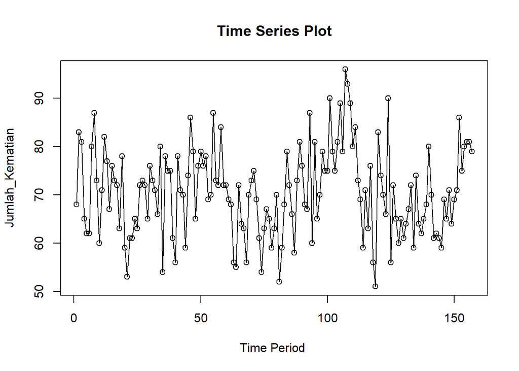

```r
ts.plot(data.ts, xlab="Time Period ", ylab="Jumlah_Kematian",
        main = "Time Series Plot")
points(data.ts)
```

Plot yang ditampilkan menunjukkan bahwa data time series yang digunakan memiliki pola konstan.

## Single Moving Average

### Pembagian Data

Pembagian data latih dan data uji dilakukan dengan perbandingan 80% data latih dan 20% data uji.

```r
#membagi data latih dan data uji
training <- data[1:126,]
testing <- data[127:157,]
training.ts <- ts(training$Jumlah_Kematian)
testing.ts <- ts(testing$Jumlah_Kematian)
```

### Eksplorasi Data

Dilakukan pada keseluruhan data, data latih, dan data uji menggunakan plot data deret waktu.

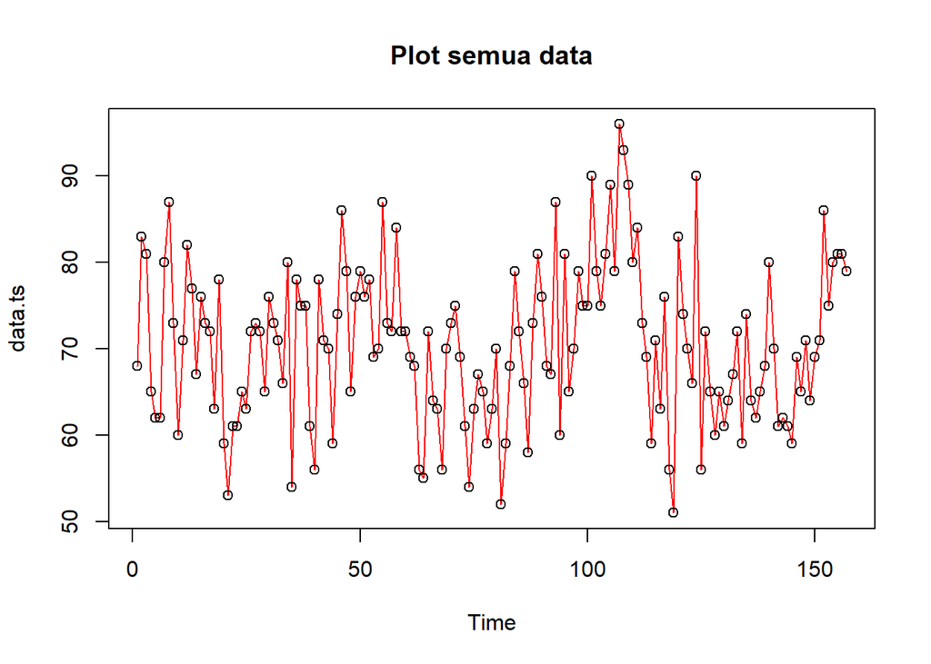

```r
#eksplorasi keseluruhan data
plot(data.ts, col="red",main="Plot semua data")
points(data.ts)
```

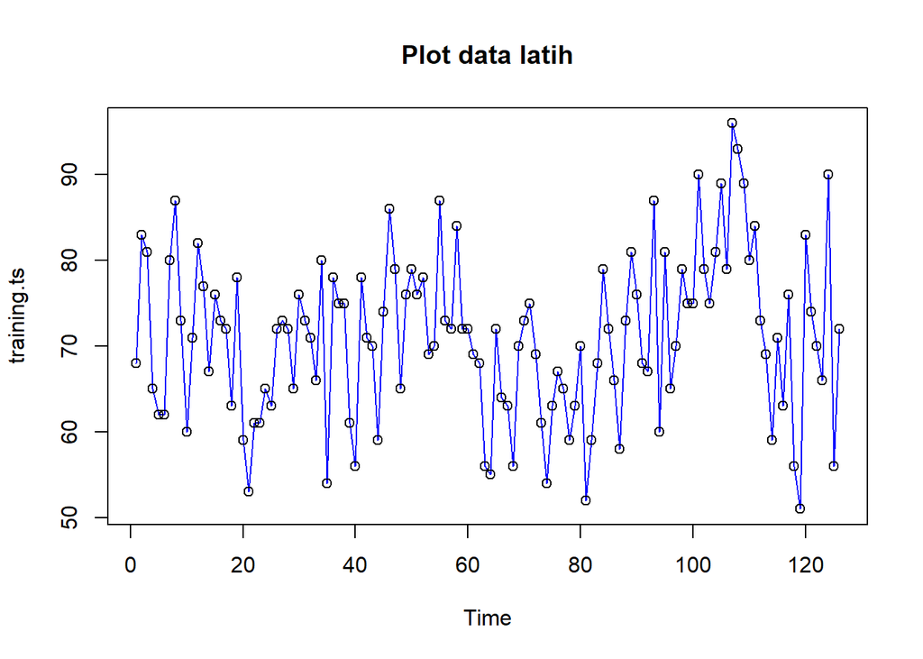

```r
#eksplorasi data latih
plot(training.ts, col="blue",main="Plot data latih")
points(training.ts)
```

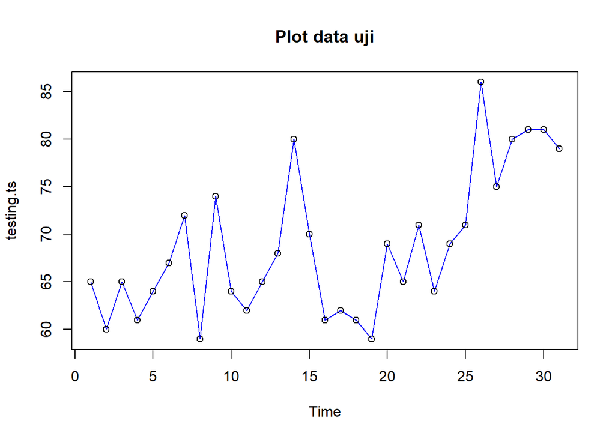

```r
#eksplorasi data uji
plot(testing.ts, col="blue",main="Plot data uji")
points(testing.ts)
```

Eksplorasi juga dapat dilakukan menggunakan package `ggplot2` .

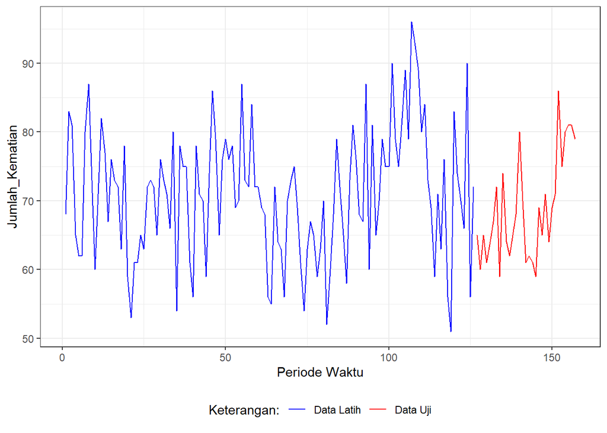

```r
#Eksplorasi dengan GGPLOT
library(ggplot2)
ggplot() +
  geom_line(data = training, aes(x = Periode, y = Jumlah_Kematian, col = "Data Latih")) +
  geom_line(data = testing, aes(x = Periode, y = Jumlah_Kematian, col = "Data Uji")) +
  labs(x = "Periode Waktu", y = "Jumlah_Kematian", color = "Legend") +
  scale_colour_manual(name="Keterangan:", breaks = c("Data Latih", "Data Uji"),
                      values = c("blue", "red")) +
  theme_bw() + theme(legend.position = "bottom",
                     plot.caption = element_text(hjust=0.5, size=12))
```

### Single Moving Average (SMA)

Ide dasar dari Single Moving Average (SMA) adalah data suatu periode dipengaruhi oleh data periode sebelumnya. Metode pemulusan ini cocok digunakan untuk pola data stasioner atau konstan. Data pemulusan pada periode ke-t merupakan rata rata dari m buah data pada periode ke-t hingga periode ke (t-m+1). Data pemulusan pada periode ke-t selanjutnya digunakan sebagai nilai peramalan pada periode ke t+1

```r
data.sma<-SMA(training.ts)
data.sma
```

```
## Time Series:
## Start = 1
## End = 126
## Frequency = 1
##   [1]   NA   NA   NA   NA   NA   NA   NA   NA   NA 72.1 72.4 72.3 71.9 72.1 73.5
##  [16] 74.6 73.8 71.4 71.9 71.8 70.0 67.9 66.3 66.1 64.8 64.7 64.8 65.7 64.4 66.1
##  [31] 68.1 69.1 69.6 71.1 70.2 70.8 71.0 71.3 70.9 68.9 69.4 69.4 69.8 67.7 69.7
##  [46] 70.5 70.9 69.9 71.4 73.7 73.5 74.2 74.1 75.2 76.5 75.2 74.5 76.4 76.0 75.3
##  [61] 74.6 73.6 72.3 70.8 69.3 68.4 67.5 64.7 64.5 64.6 65.2 65.3 65.8 65.7 64.8
##  [76] 65.1 65.3 65.6 64.9 64.6 62.3 61.3 62.0 64.5 65.4 65.3 64.6 66.0 67.8 68.4
##  [91] 70.0 70.8 72.7 70.8 71.7 71.6 72.8 73.4 72.8 72.7 74.9 76.1 74.9 77.0 77.8
## [106] 79.2 81.8 83.2 84.6 85.1 84.5 83.9 83.3 81.1 79.3 77.7 75.7 72.0 68.2 68.5
## [121] 67.5 67.2 66.9 70.0 68.5 69.4
```

Data pemulusan pada periode ke-t selanjutnya digunakan sebagai nilai peramalan pada periode ke t+1 sehingga hasil peramalan 1 periode kedepan adalah sebagai berikut.

```r
data.ramal<-c(NA,data.sma)
data.ramal #forecast 1 periode ke depan
```

```
##   [1]   NA   NA   NA   NA   NA   NA   NA   NA   NA   NA 72.1 72.4 72.3 71.9 72.1
##  [16] 73.5 74.6 73.8 71.4 71.9 71.8 70.0 67.9 66.3 66.1 64.8 64.7 64.8 65.7 64.4
##  [31] 66.1 68.1 69.1 69.6 71.1 70.2 70.8 71.0 71.3 70.9 68.9 69.4 69.4 69.8 67.7
##  [46] 69.7 70.5 70.9 69.9 71.4 73.7 73.5 74.2 74.1 75.2 76.5 75.2 74.5 76.4 76.0
##  [61] 75.3 74.6 73.6 72.3 70.8 69.3 68.4 67.5 64.7 64.5 64.6 65.2 65.3 65.8 65.7
##  [76] 64.8 65.1 65.3 65.6 64.9 64.6 62.3 61.3 62.0 64.5 65.4 65.3 64.6 66.0 67.8
##  [91] 68.4 70.0 70.8 72.7 70.8 71.7 71.6 72.8 73.4 72.8 72.7 74.9 76.1 74.9 77.0
## [106] 77.8 79.2 81.8 83.2 84.6 85.1 84.5 83.9 83.3 81.1 79.3 77.7 75.7 72.0 68.2
## [121] 68.5 67.5 67.2 66.9 70.0 68.5 69.4
```

```r
data.gab<-cbind(aktual=c(training.ts,rep(NA,32)),pemulusan=c(data.sma,rep(NA,32)),ramalan=c(data.ramal,rep(data.ramal[length(data.ramal)],31)))
data.gab #forecast 32 periode ke depan
```

```
##        aktual pemulusan ramalan
##   [1,]     68        NA      NA
##   [2,]     83        NA      NA
##   [3,]     81        NA      NA
##   [4,]     65        NA      NA
##   [5,]     62        NA      NA
##   [6,]     62        NA      NA
##   [7,]     80        NA      NA
##   [8,]     87        NA      NA
##   [9,]     73        NA      NA
##  [10,]     60      72.1      NA
##  [11,]     71      72.4    72.1
##  [12,]     82      72.3    72.4
##  [13,]     77      71.9    72.3
##  [14,]     67      72.1    71.9
```

[output cut: 144 more lines]

Plot data deret waktu dari hasil peramalan yang dilakukan:

[figure not shown]

```r
ts.plot(data.ts, xlab="Time Period ", ylab="Jumlah_Kematian", main= "SMA N=11 Data Jumlah Kematian")
points(data.ts)
lines(data.gab[,2],col="green",lwd=2)
lines(data.gab[,3],col="red",lwd=2)
legend("topleft",c("data aktual","data pemulusan","data peramalan"), lty=8, col=c("black","green","red"), cex=0.5)
```

Selanjutnya perhitungan akurasi dilakukan dengan ukuran akurasi *Sum Squares Error* (SSE), *Mean Square Error* (MSE) dan *Mean Absolute Percentage Error* (MAPE). Perhitungan akurasi dilakukan baik pada data latih maupun pada data uji.

```r
#Menghitung nilai keakuratan data latih
error_train.sma = training.ts-data.ramal[1:length(training.ts)]
SSE_train.sma = sum(error_train.sma[12:length(training.ts)]^2)
MSE_train.sma = mean(error_train.sma[12:length(training.ts)]^2)
MAPE_train.sma = mean(abs((error_train.sma[12:length(training.ts)]/training.ts[12:length(training.ts)])*100))

akurasi_train.sma <- matrix(c(SSE_train.sma, MSE_train.sma, MAPE_train.sma))
row.names(akurasi_train.sma)<- c("SSE", "MSE", "MAPE")
colnames(akurasi_train.sma) <- c("Akurasi m = 11")
akurasi_train.sma
```

```
##      Akurasi m = 11
## SSE     10305.24000
## MSE        89.61078
## MAPE       11.24701
```

```r
#Menghitung nilai keakuratan data uji
error_test.sma = testing.ts-data.gab[127:157,3]
SSE_test.sma = sum(error_test.sma^2)
MSE_test.sma = mean(error_test.sma^2)
MAPE_test.sma = mean(abs((error_test.sma/testing.ts*100)))

akurasi_test.sma <- matrix(c(SSE_test.sma, MSE_test.sma, MAPE_test.sma))
row.names(akurasi_test.sma)<- c("SSE", "MSE", "MAPE")
colnames(akurasi_test.sma) <- c("Akurasi m = 11")
akurasi_test.sma
```

```
##      Akurasi m = 11
## SSE     1725.160000
## MSE       55.650323
## MAPE       9.178951
```

## Single Exponential Smoothing

Single Exponential Smoothing merupakan metode pemulusan yang tepat digunakan untuk data dengan pola stasioner atau konstan.

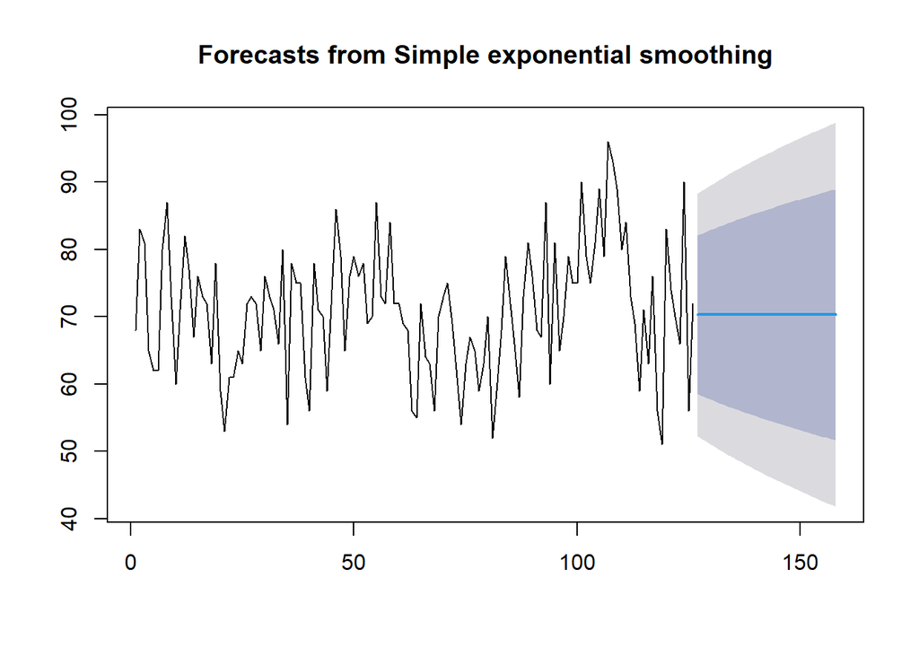

```r
#Cara 1 (fungsi ses)
ses.1 <- ses(training.ts, h = 32, alpha = NULL)
plot(ses.1)
```

```r
ses.1
```

```
##     Point Forecast    Lo 80    Hi 80    Lo 95    Hi 95
## 127       70.30748 58.53812 82.07684 52.30780 88.30716
## 128       70.30748 58.25463 82.36033 51.87424 88.74072
## 129       70.30748 57.97766 82.63731 51.45064 89.16432
## 130       70.30748 57.70677 82.90819 51.03636 89.57861
## 131       70.30748 57.44158 83.17338 50.63079 89.98418
## 132       70.30748 57.18175 83.43321 50.23341 90.38155
## 133       70.30748 56.92697 83.68799 49.84375 90.77121
## 134       70.30748 56.67695 83.93802 49.46138 91.15359
## 135       70.30748 56.43143 84.18354 49.08589 91.52908
## 136       70.30748 56.19018 84.42479 48.71693 91.89803
## 137       70.30748 55.95298 84.66198 48.35417 92.26079
## 138       70.30748 55.71964 84.89532 47.99731 92.61766
## 139       70.30748 55.48998 85.12499 47.64607 92.96890
## 140       70.30748 55.26382 85.35114 47.30018 93.31478
```

[output cut: 18 more lines]

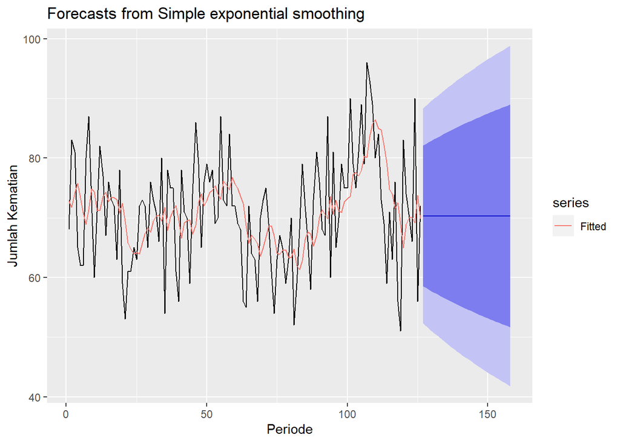

```r
autoplot(ses.1) +
  autolayer(fitted(ses.1), series="Fitted") +
  ylab("Jumlah Kematian") + xlab("Periode")
```

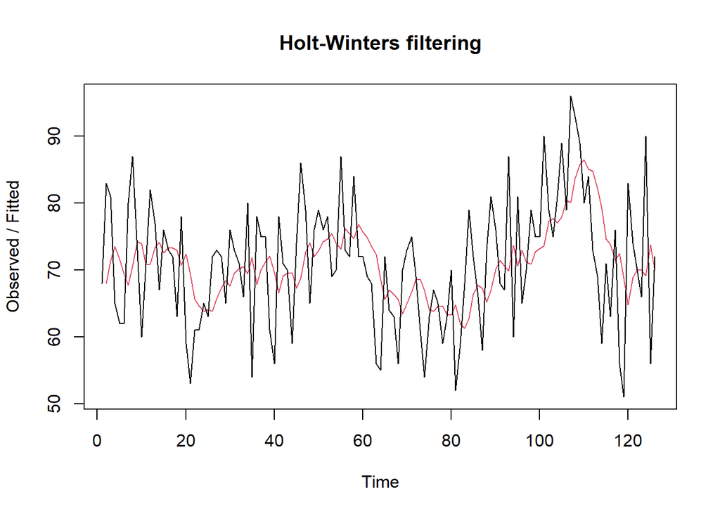

```r
#Cara 2 (fungsi Holtwinter)
ses.2<- HoltWinters(training.ts, gamma = FALSE, beta = FALSE, alpha = NULL)
plot(ses.2)
```

```r
#ramalan
ramalan<- forecast(ses.2, h=32)
ramalan
```

```
##     Point Forecast    Lo 80    Hi 80    Lo 95    Hi 95
## 127       70.29756 58.49549 82.09962 52.24786 88.34725
## 128       70.29756 58.20259 82.39252 51.79990 88.79521
## 129       70.29756 57.91662 82.67849 51.36255 89.23256
## 130       70.29756 57.63710 82.95801 50.93507 89.66004
## 131       70.29756 57.36363 83.23148 50.51682 90.07829
## 132       70.29756 57.09582 83.49929 50.10724 90.48787
## 133       70.29756 56.83333 83.76178 49.70580 90.88931
## 134       70.29756 56.57586 84.01925 49.31204 91.28307
## 135       70.29756 56.32314 84.27197 48.92553 91.66958
## 136       70.29756 56.07491 84.52020 48.54589 92.04922
## 137       70.29756 55.83093 84.76418 48.17277 92.42234
## 138       70.29756 55.59101 85.00410 47.80583 92.78928
## 139       70.29756 55.35493 85.24018 47.44478 93.15033
## 140       70.29756 55.12253 85.47258 47.08935 93.50576
```

[output cut: 18 more lines]

```r
#Keakuratan Metode
#Pada data training
SSE2<-ses.2$SSE
MSE2<-ses.2$SSE/length(training.ts)
RMSE2<-sqrt(MSE2)

akurasi <- matrix(c(SSE2,MSE2,RMSE2))
row.names(akurasi)<- c("SSE", "MSE", "RMSE")
colnames(akurasi) <- c("Akurasi lamda = NULL")
akurasi
```

```
##      Akurasi lamda = NULL
## SSE          10517.198564
## MSE             83.469830
## RMSE             9.136182
```

#### Akurasi Data Uji

```r
accuracy(ramalan,testing$Jumlah_Kematian)
```

```
##                       ME     RMSE      MAE       MPE      MAPE      MASE
## Training set  0.08199398 9.172654 7.493348 -1.430619 10.869323 0.8333349
## Test set     -1.58787759 7.595731 6.538000 -3.451139  9.617125 0.7270907
##                    ACF1
## Training set 0.05059694
## Test set             NA
```

Pada metode pemulusan SMA dihasilkan nilai MAPE sebesar 11.24701 untuk data training dan 9.178951 untuk data testing. Sementara itu, pada metode pemulusan SES dihasilkan nilai MAPE sebesar 10.869323 untuk data training dan 9.617125 untuk data testing. Dapat disimpulkan bahwa pada data training, metode SES lebih baik dibandingkan dengan metode SMA, sedangkan pada data testing, metode SMA lebih baik dibandingkan SES.